# DESeq analysis of Pasilla knock-downs

This guide follows the [Bioconductor RNA-Seq workflow](http://www.bioconductor.org/help/workflows/rnaseqGene) to find differentially expressed genes using [DESeq2](http://www.bioconductor.org/packages/release/bioc/html/DESeq2.html). Load the hciR package on Github to run the [R](https://www.r-project.org) code.

You can render this HTML report by finding the path to the DESeq.Rmd file in `inst/Rmd`.

```r
library(hciR)
rmd <- system.file("Rmd", "DESeq.Rmd", package="hciR")
render(rmd, "pasilla_DESeq.html", output_dir=".")
```

### Load samples and counts

Load the [pasilla](http://bioconductor.org/packages/release/data/experiment/html/pasilla.html) counts and samples and fix the file name to match column names in the count matrix.

```r
setwd( system.file("extdata", package="pasilla") )
counts  <- read_tsv("pasilla_gene_counts.tsv" )
samples <- read_csv("pasilla_sample_annotation.csv")
samples$file <- gsub("fb$", "", samples$file )
samples
#  # A tibble: 7 × 6
#          file condition        type `number of lanes` `total number of reads` `exon counts`
#         <chr>     <chr>       <chr>             <int>                   <chr>         <int>
#  1   treated1   treated single-read                 5                35158667      15679615
#  2   treated2   treated  paired-end                 2           12242535 (x2)      15620018
#  3   treated3   treated  paired-end                 2           12443664 (x2)      12733865
#  4 untreated1 untreated single-read                 2                17812866      14924838
#  5 untreated2 untreated single-read                 6                34284521      20764558
#  6 untreated3 untreated  paired-end                 2           10542625 (x2)      10283129
#  7 untreated4 untreated  paired-end                 2           12214974 (x2)      11653031
```

Remove 2240 features with zero counts and 1323 with one or fewer reads in any sample.

```r
counts <- filter_counts(counts)
#  Removed 2240 features with 0 reads
#  Removed 1323 features with <=1 maximum reads
counts
#  # A tibble: 11,036 × 8
#         gene_id untreated1 untreated2 untreated3 untreated4 treated1 treated2 treated3
#           <chr>      <int>      <int>      <int>      <int>    <int>    <int>    <int>
#  1  FBgn0000008         92        161         76         70      140       88       70
#  2  FBgn0000014          5          1          0          0        4        0        0
#  3  FBgn0000015          0          2          1          2        1        0        0
#  4  FBgn0000017       4664       8714       3564       3150     6205     3072     3334
#  5  FBgn0000018        583        761        245        310      722      299      308
#  6  FBgn0000024         10         11          3          3       10        7        5
#  7  FBgn0000032       1446       1713        615        672     1698      696      757
#  8  FBgn0000036          2          1          0          0        1        0        1
#  9  FBgn0000037         15         25          9          5       20       14       17
#  10 FBgn0000042     101664     120163      45880      53201   127363    76099    83164
#  # ... with 11,026 more rows
```

### Run DESeq

Combine the counts and samples to create a `DESeqDataSet` object and calculate the regularized log transform (rlog) for sample visualizations.

```r
dds <- deseq_from_tibble(counts, samples,  design = ~ condition)
#  Reordering columns in counts to match samples
#  estimating size factors
#  estimating dispersions
#  gene-wise dispersion estimates
#  mean-dispersion relationship
#  final dispersion estimates
#  fitting model and testing
rld <- r_log(dds)
```

### PCA plot

Plot the first two principal components using the rlog values from the top 500 variable genes. You can hover over points to view sample names and type or zoom into groups of points in this interactive [highchart](http://jkunst.com/highcharter/index.html).

```r
plot_pca(rld, "condition", tooltip=c("file", "type") , width=700)
```

[interactive chart not shown]

Cluster all the rlog values using the R function `dist` to calculate the Euclidean distance between samples.

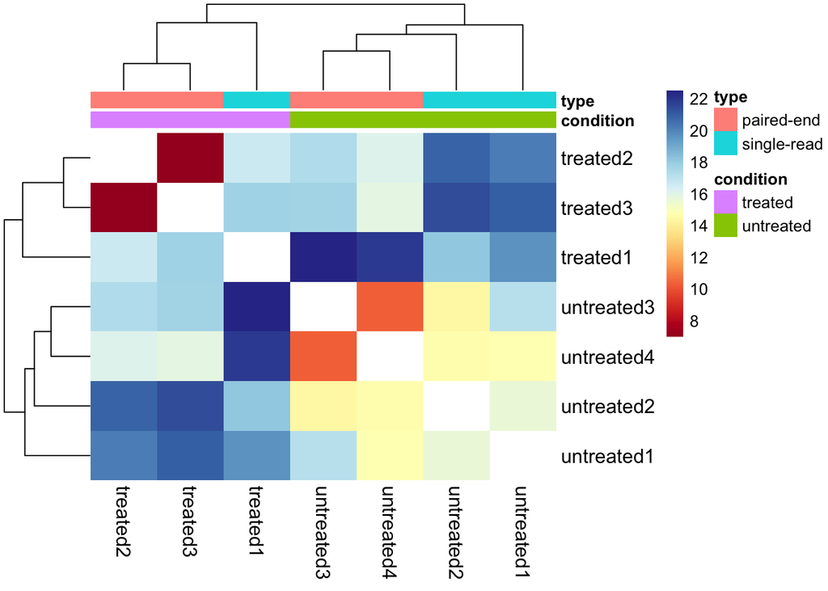

```r
plot_dist(rld , c("condition", "type"))
```

### Gene annotations

Load fruitfly annotations from Ensembl.

```r
fly <- read_biomart("fly")
#  Downloaded 19639 results, grouping into 17559 rows with a unique Ensembl ID
```

### Result tables

Get the DESeq results using a 5% false discovery rate (FDR). This function will compare alll treatment combinations, which only includes one in this study.

```r
res <- results_all(dds, fly, alpha= 0.05)
#  Using adjusted p-value < 0.05
#
#  1. treated vs. untreated: 412 up and 438 down regulated
#  Note: 723 rows in results are missing from biomart table
datatable(top_genes(res)[, c(1:2, 4:7, 11)], options=list(pageLength=5) ) %>%
  formatRound(5:6, 2) %>% formatSignif(7,2)
```

|  | id | gene_name | chromosome | description | baseMean | log2FoldChange | padj |
| --- | --- | --- | --- | --- | --- | --- | --- |
| 1 | FBgn0039155 | Kal1 | 3R | Kallmann syndrome 1 ortholog | 730.595806139728 | -4.09779949635054 | 2.14130858296198e-177 |
| 2 | FBgn0025111 | Ant2 | X | Adenine nucleotide translocase 2 | 1501.41051323996 | 2.70274492491026 | 2.11788175615645e-112 |
| 3 | FBgn0029167 | Hml | 3L | Hemolectin | 3706.11653071978 | -2.10643816735428 | 2.87005597964393e-110 |
| 4 | FBgn0003360 | sesB | X | stress-sensitive B | 4343.03539692487 | -2.90352570380087 | 1.42290378539127e-105 |
| 5 | FBgn0039827 | CG1544 | 3R |  | 261.916235943103 | -3.36718338025346 | 1.89659048852211e-78 |
| 6 | FBgn0035085 | CG3770 | 2R |  | 638.232608936723 | -2.35662277631443 | 1.63343220498108e-75 |
| 7 | FBgn0034736 | CG6018 | 2R |  | 225.876362546023 | -2.91229316751861 | 1.76039702702432e-62 |
| 8 | FBgn0029896 | CG3168 | X |  | 489.892369695729 | -2.21232701515021 | 3.82119064241113e-56 |
| 9 | FBgn0000071 | Ama | 3R | Amalgam | 342.2384071951 | 2.32888736576482 | 2.20325253098151e-46 |
| 10 | FBgn0034434 |  |  |  | 114.625559330683 | -2.74620801319249 | 7.43313832325324e-43 |

[output cut: 30 more lines]

### Browse results

Create a [flex dashboard](http://rmarkdown.rstudio.com/flexdashboard/) using the top 1000 genes sorted by p-value in pasilla_flex.html. The [MA-plot](https://en.wikipedia.org/wiki/MA_plot) and volcano plot are linked, so you can click and drag to create a box to highlight points and then view matching rows in the table. You can also drag the box around the plot to easily highlight other points and rows. In addition, you can search for genes in the table using the search box, but need to click on the row in order to highlight the points in the plots. The sliders can also be used to limit the results.

```r
rmd <- system.file("Rmd", "DESeq_flex.Rmd", package="hciR")
render(rmd, output_file="pasilla_flex.html",  output_dir=".",
         params=list( results= res, title = "Pasilla treated vs. untreated", top= 1000 ))
```

### Save results

Save the DESeq results to a single Excel file in DESeq.xlsx. The `write_deseq` function will also output raw counts, rlog values, normalized counts, samples and fly annotations.

```r
write_deseq( dds, res, rld, fly)
```

### Plot heatmaps

Select the top 40 genes sorted by p-value and cluster the rlog differences, so values in the heatmap represent the amount a gene deviates in a specific sample from the gene’s average across all samples.

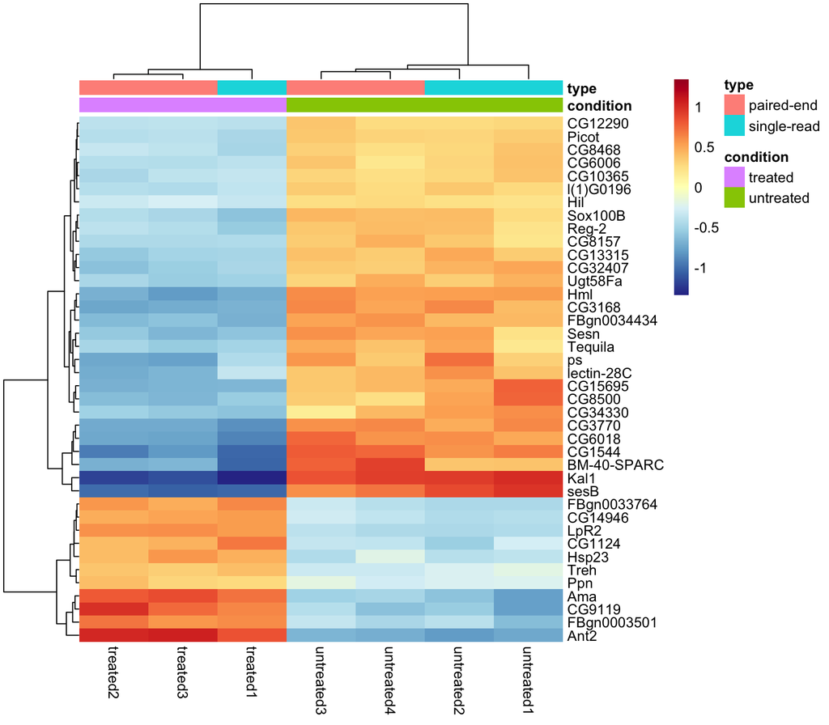

```r
plot_genes( top_counts( res, rld), c("condition", "type") )
```

Plot the top 400 genes using an interactive [d3heatmap](http://www.htmlwidgets.org/showcase_d3heatmap.html). Click and drag over a region in the plot to zoom and better view gene labels.

```r
plot_genes( top_counts( res, rld, top=400), output="d3", xaxis_font_size=12)
```

[interactive chart not shown]